# Bayesian linear models

When doing so, ideally the posterior should be distinct from the prior. By distinct, I mean that the posteriors should be clearly distinguishable from the priors. Ideally, the priors should be less variable than the priors. If this is not the case, it might suggest that the posteriors are being too strongly driven by the priors.

```r
dat2b.brm2 |> tidybayes::get_variables()
```

```
 [1] "b_xcontrol"    "b_xmedium"     "b_xhigh"       "sigma"
 [5] "prior_b"       "prior_sigma"   "lprior"        "lp__"
 [9] "accept_stat__" "stepsize__"    "treedepth__"   "n_leapfrog__"
[13] "divergent__"   "energy__"
```

```r
dat2b.brm2 |> hypothesis("xcontrol = 0") |> plot()
```

[output not shown]

```r
dat2b.brm2 |> hypothesis("xmedium = 0") |> plot()
```

[output not shown]

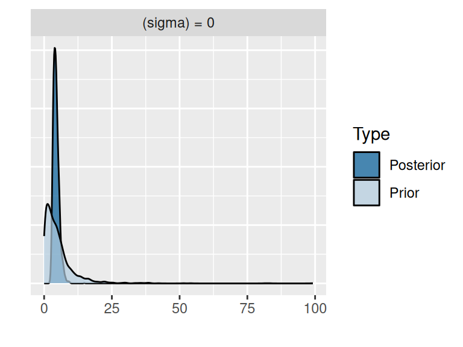

```r
dat2b.brm2 |> hypothesis("sigma = 0", class = "") |> plot()
```

```r
dat2b.brm2 |> tidybayes::get_variables()
```

```
 [1] "b_xcontrol"    "b_xmedium"     "b_xhigh"       "sigma"
 [5] "prior_b"       "prior_sigma"   "lprior"        "lp__"
 [9] "accept_stat__" "stepsize__"    "treedepth__"   "n_leapfrog__"
[13] "divergent__"   "energy__"
```

```r
#dat2b.brm2 |> SUYR_prior_and_posterior()
```

**Conclusions:**

- each of the priors are substantially wider than the posteriors
- the posteriors are definitely distinct from their respective priors and thus we can conclude that the priors and not driving the posteriors (e.g. they are not influencing the outcomes)
- the priors are simply regularising the parameters such that they are only sampled from plausible regions

**Example 3 (Poisson data)**

**Raw predictor**

$$\begin{align}
y_i \sim{}& Pois(\lambda_i)\\
log(\lambda_i) =& \beta_0 + \beta_1 x_i\\
\end{align}$$

**Define priors**

When considering priors, it is important to remember that they apply to parameters on the link scale. For Poisson models, the link scale is log. So the following priors might be appropriate:

- $\beta_0$: Normal prior centred at 1.99 with a variance of 1.33
  - mean:

    ```r
    dat3$y |>
        log() |>
        median() |>
        round(2)
    ```

    ```
    [1] 1.99
    ```

  - variance:

    ```r
    dat3$y |>
        log() |>
        mad() |>
        round(2)
    ```

    ```
    [1] 1.33
    ```

- $\beta_1$: *t* distribution (3 degrees of freedom) prior centred at 0 with a variance of 2.05
  - mean: since effects are differences and we may not want to pre-determine the direction (polarity) of any trends, it is typical to define effects priors with means of 0
  - variance:

    ```r
    dat3 |>
        mutate(across(c(y, x), log)) |>
        summarise(across(c(y, x), mad)) |>
        mutate(round(y / x, 2))
    ```

    ```
             y        x round(y/x, 2)
    1 1.328231 0.648985          2.05
    ```

```r
priors <- prior(normal(2.00, 1.33), class = "Intercept") +
    prior(student_t(3, 0, 2.00), class = "b")
```

**Fit the model**

1. start by fitting the model and sampling from the priors only

```r
dat3a.form <- bf(y ~ x, family = poisson(link = "log"))
dat3a.brm <- brm(dat3a.form,
                data=dat3,
                prior=priors,
                sample_prior = 'only',
                iter = 5000,
                warmup = 1000,
                chains = 3, cores = 3,
                thin = 5,
                #backend = 'cmdstan',
                refresh = 0)
```

2. explore the range of posterior predictions resulting from the priors alone

```
Ignoring unknown labels:
• fill : "NA"
• colour : "NA"
Ignoring unknown labels:
• fill : "NA"
• colour : "NA"
```

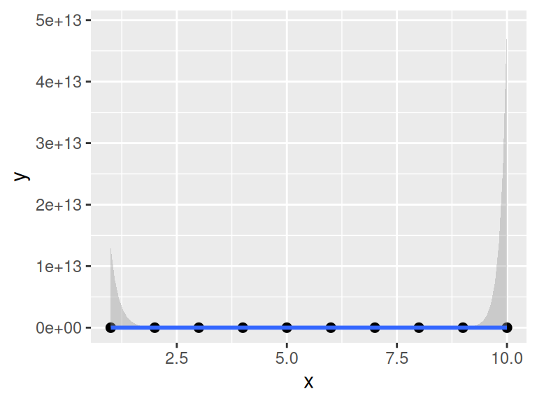

```
Ignoring unknown labels:
• fill : "NA"
• colour : "NA"
```

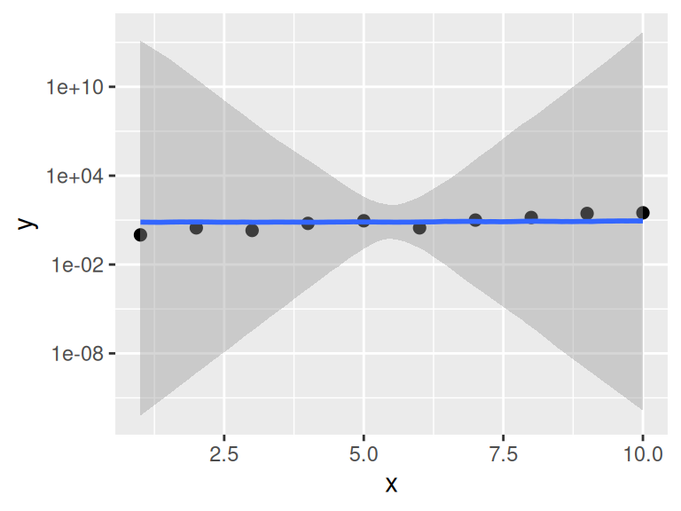

```r
dat3a.brm |>
  conditional_effects() |>
  plot(points = TRUE) |> _[[1]] +
  scale_y_log10()
```

**Conclusions:**

```r
dat3a.brm2 <- update(dat3a.brm,
    sample_prior = "yes"
)
```

```
The desired updates require recompiling the model
```

4. re-explore the range of posterior predictions resulting from the fitted model

```
Ignoring unknown labels:
• fill : "NA"
• colour : "NA"
Ignoring unknown labels:
• fill : "NA"
• colour : "NA"
```

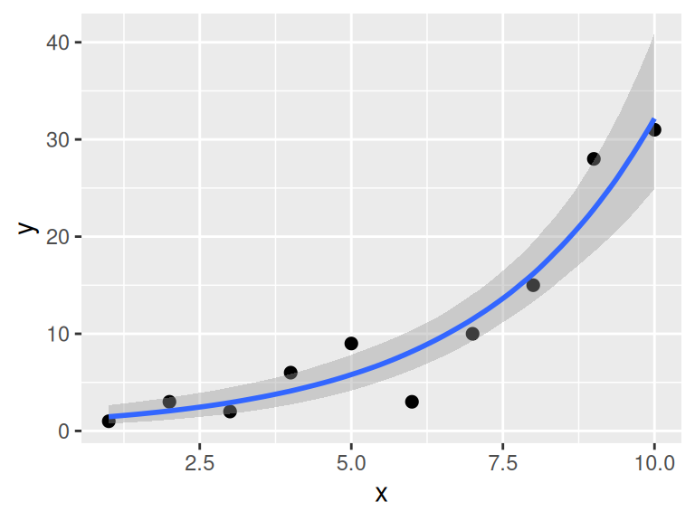

```r
dat3a.brm2 |>
    conditional_effects() |>
    plot(points = TRUE)
```

**Conclusions:**

- the range of the posteriors are now substantially reduced (now that the model includes both data and priors)
- this suggests that the patterns are being driven predominantly by the data
5. compare the priors and posteriors to further confirm that the priors are not overly influential

When we have indicated that the posterior should be informed by both the prior and the posterior, both prior (governed by priors alone) and posterior (governed by both priors and data/likelihood) draws are returned. These can be compared by exploring the probabilities associated with specific hypotheses - the most obvious of which is that of no effect (that the parameter = 0).

When doing so, ideally the posterior should be distinct from the prior. By distinct, I mean that the posteriors should be clearly distinguishable from the priors. Ideally, the priors should be less variable than the priors. If this is not the case, it might suggest that the posteriors are being too strongly driven by the priors.

```r
dat3a.brm2 |> tidybayes::get_variables()
```

```
 [1] "b_Intercept"     "b_x"             "Intercept"       "prior_Intercept"
 [5] "prior_b"         "lprior"          "lp__"            "accept_stat__"
 [9] "stepsize__"      "treedepth__"     "n_leapfrog__"    "divergent__"
[13] "energy__"
```

```r
dat3a.brm2 |> hypothesis("x = 0") |> plot()
```

[output not shown]

Unfortunately, it is not possible to do this comparison sensibly for the intercept. The reason for this is that the prior for intercept was applied to an intercept that is associated with centred continuous predictors (predictors are centred behind the scenes). Since we did not centre the predictor, the intercept returned is as if uncentred. Hence, the prior and posterior are on different scales.

```r
dat3a.brm2 |> tidybayes::get_variables()
```

```
 [1] "b_Intercept"     "b_x"             "Intercept"       "prior_Intercept"
 [5] "prior_b"         "lprior"          "lp__"            "accept_stat__"
 [9] "stepsize__"      "treedepth__"     "n_leapfrog__"    "divergent__"
[13] "energy__"
```

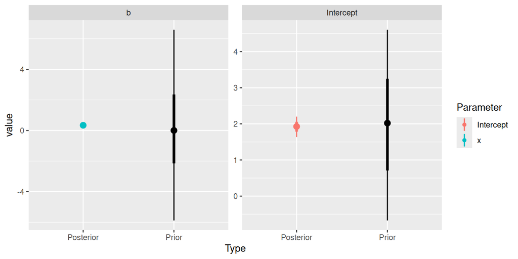

```r
dat3a.brm2 |> SUYR_prior_and_posterior()
```

**Conclusions:**

- each of the priors are substantially wider than the posteriors
- the posteriors are definitely distinct from their respective priors and thus we can conclude that the priors and not driving the posteriors (e.g. they are not influencing the outcomes)
- the priors are simply regularising the parameters such that they are only sampled from plausible regions

**Centered predictor**

$$\begin{align}
y_i \sim{}& Pois(\mu_i)\\
log(\mu_i) =& \beta_0 + (\beta_1 x_i - \bar{x})\\
\end{align}$$

**Define priors**

When considering priors, it is important to remember that they apply to parameters on the link scale. For Poisson models, the link scale is log. So the following priors might be appropriate:

- $\beta_0$: Normal prior centred at 1.99 with a variance of 1.33
  - mean:

    ```r
    dat3$y |>
        log() |>
        median() |>
        round(2)
    ```

    ```
    [1] 1.99
    ```

  - variance:

    ```r
    dat3$y |>
        log() |>
        mad() |>
        round(2)
    ```

    ```
    [1] 1.33
    ```

- $\beta_1$: *t* distribution (3 degrees of freedom) prior centred at 0 with a variance of 2.05
  - mean: since effects are differences and we may not want to pre-determine the direction (polarity) of any trends, it is typical to define effects priors with means of 0
  - variance:

    ```r
    dat3 |>
        mutate(across(c(y, x), log)) |>
        summarise(across(c(y, x), mad)) |>
        mutate(round(y / x, 2))
    ```

    ```
             y        x round(y/x, 2)
    1 1.328231 0.648985          2.05
    ```

```r
priors <- prior(normal(2.00, 1.33), class = "Intercept") +
    prior(student_t(3, 0, 2.00), class = "b")
```

**Fit the model**

1. start by fitting the model and sampling from the priors only

```r
dat3b.form <- bf(y ~ scale(x, scale = FALSE), family = poisson(link = "log"))
dat3b.brm <- brm(dat3b.form,
                data=dat3,
                prior=priors,
                sample_prior = 'only',
                iter = 5000,
                warmup = 1000,
                chains = 3, cores = 3,
                thin = 5,
                #backend = 'cmdstan',
                refresh = 0)
```

2. explore the range of posterior predictions resulting from the priors alone

```
Ignoring unknown labels:
• fill : "NA"
• colour : "NA"
Ignoring unknown labels:
• fill : "NA"
• colour : "NA"
```

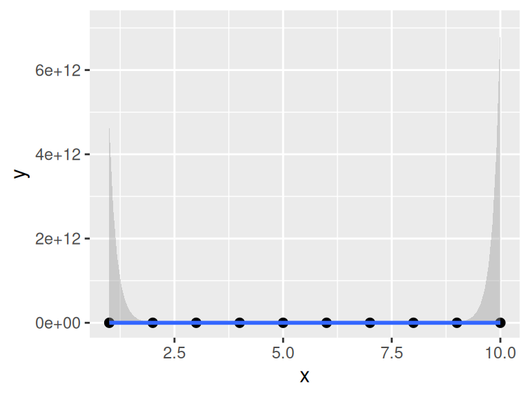

```
Ignoring unknown labels:
• fill : "NA"
• colour : "NA"
```

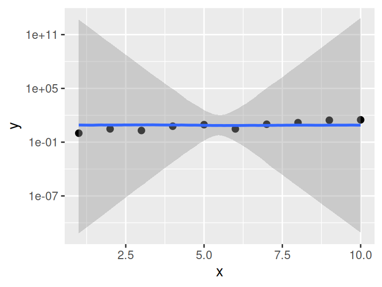

```r
dat3b.brm |>
  conditional_effects() |>
  plot(points = TRUE) |> _[[1]] +
  scale_y_log10()
```

**Conclusions:**

```r
dat3b.brm2 <- update(dat3b.brm,
    sample_prior = "yes"
)
```

```
The desired updates require recompiling the model
```

4. re-explore the range of posterior predictions resulting from the fitted model

```
Ignoring unknown labels:
• fill : "NA"
• colour : "NA"
Ignoring unknown labels:
• fill : "NA"
• colour : "NA"
```

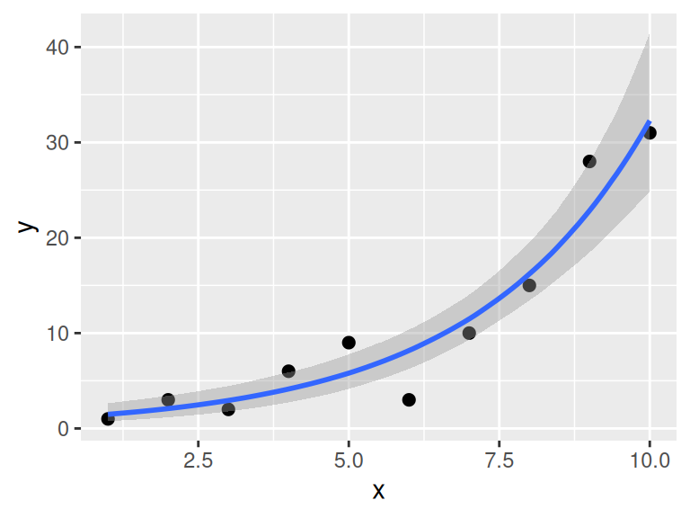

```r
dat3b.brm2 |>
    conditional_effects() |>
    plot(points = TRUE)
```

**Conclusions:**

- the range of the posteriors are now substantially reduced (now that the model includes both data and priors)
- this suggests that the patterns are being driven predominantly by the data
5. compare the priors and posteriors to further confirm that the priors are not overly influential

When we have indicated that the posterior should be informed by both the prior and the posterior, both prior (governed by priors alone) and posterior (governed by both priors and data/likelihood) draws are returned. These can be compared by exploring the probabilities associated with specific hypotheses - the most obvious of which is that of no effect (that the parameter = 0).

When doing so, ideally the posterior should be distinct from the prior. By distinct, I mean that the posteriors should be clearly distinguishable from the priors. Ideally, the priors should be less variable than the priors. If this is not the case, it might suggest that the posteriors are being too strongly driven by the priors.

```r
dat3b.brm2 |> tidybayes::get_variables()
```

```
 [1] "b_Intercept"          "b_scalexscaleEQFALSE" "Intercept"
 [4] "prior_Intercept"      "prior_b"              "lprior"
 [7] "lp__"                 "accept_stat__"        "stepsize__"
[10] "treedepth__"          "n_leapfrog__"         "divergent__"
[13] "energy__"
```

```r
dat3b.brm2 |> hypothesis("scalexscaleEQFALSE = 0") |> plot()
```

[output not shown]

```r
dat3b.brm2 |> tidybayes::get_variables()
```

```
 [1] "b_Intercept"          "b_scalexscaleEQFALSE" "Intercept"
 [4] "prior_Intercept"      "prior_b"              "lprior"
 [7] "lp__"                 "accept_stat__"        "stepsize__"
[10] "treedepth__"          "n_leapfrog__"         "divergent__"
[13] "energy__"
```

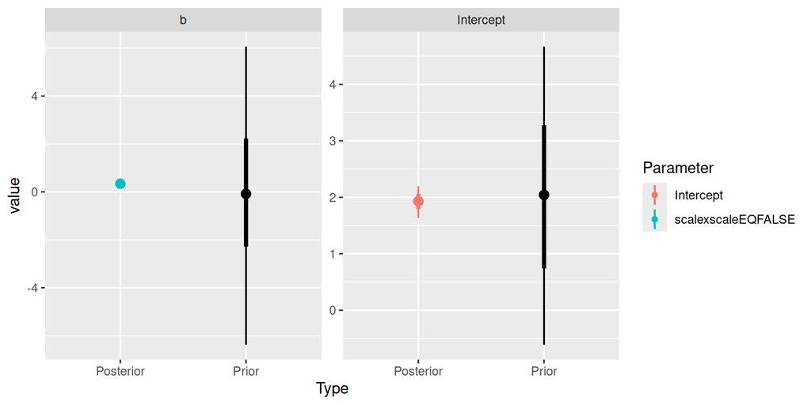

```r
dat3b.brm2 |> SUYR_prior_and_posterior()
```

**Conclusions:**

- each of the priors are substantially wider than the posteriors
- the posteriors are definitely distinct from their respective priors and thus we can conclude that the priors and not driving the posteriors (e.g. they are not influencing the outcomes)
- the priors are simply regularising the parameters such that they are only sampled from plausible regions

**Standardised predictor**

$$\begin{align}
y_i \sim{}& Pois(\lambda_i)\\
log(\lambda_i) =& \beta_0 + (\beta_1 x_i - \bar{x})/\sigma_x\\
\end{align}$$

**Define priors**

When considering priors, it is important to remember that they apply to parameters on the link scale. For Poisson models, the link scale is log. So the following priors might be appropriate:

- $\beta_0$: Normal prior centred at 1.99 with a variance of 1.33
  - mean:

    ```r
    dat3$y |>
        log() |>
        median() |>
        round(2)
    ```

    ```
    [1] 1.99
    ```

  - variance:

    ```r
    dat3$y |>
        log() |>
        mad() |>
        round(2)
    ```

    ```
    [1] 1.33
    ```

- $\beta_1$: *t* distribution (3 degrees of freedom) prior centred at 0 with a variance of 1.33
  - mean: since effects are differences and we may not want to pre-determine the direction (polarity) of any trends, it is typical to define effects priors with means of 0
  - variance:

    ```r
    dat3$y |> log() |> mad() |> round(2)
    ```

    ```
    [1] 1.33
    ```

```r
priors <- prior(normal(2.00, 1.33), class = "Intercept") +
    prior(student_t(3, 0, 1.33), class = "b")
```

**Fit the model**

1. start by fitting the model and sampling from the priors only

```r
dat3c.form <- bf(y ~ scale(x), family = poisson(link = "log"))
dat3c.brm <- brm(dat3c.form,
                data=dat3,
                prior=priors,
                sample_prior = 'only',
                iter = 5000,
                warmup = 1000,
                chains = 3, cores = 3,
                thin = 5,
                #backend = 'cmdstan',
                refresh = 0)
```

2. explore the range of posterior predictions resulting from the priors alone

```
Ignoring unknown labels:
• fill : "NA"
• colour : "NA"
Ignoring unknown labels:
• fill : "NA"
• colour : "NA"
```

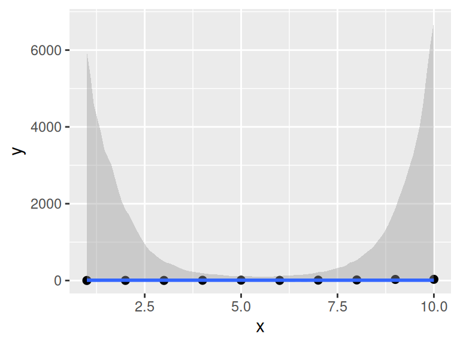

```
Ignoring unknown labels:
• fill : "NA"
• colour : "NA"
```

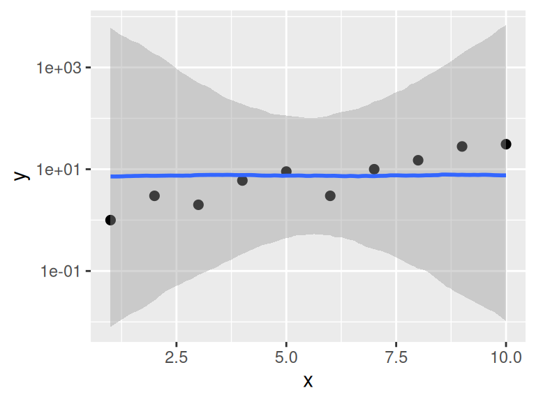

```r
dat3c.brm |>
  conditional_effects() |>
  plot(points = TRUE) |> _[[1]] +
  scale_y_log10()
```

**Conclusions:**

```r
dat3c.brm2 <- update(dat3c.brm,
    sample_prior = "yes"
)
```

```
The desired updates require recompiling the model
```

4. re-explore the range of posterior predictions resulting from the fitted model

```
Ignoring unknown labels:
• fill : "NA"
• colour : "NA"
Ignoring unknown labels:
• fill : "NA"
• colour : "NA"
```

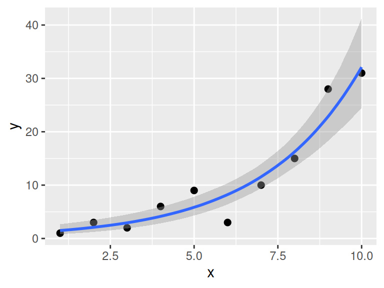

```r
dat3c.brm2 |>
    conditional_effects() |>
    plot(points = TRUE)
```

**Conclusions:**

- the range of the posteriors are now substantially reduced (now that the model includes both data and priors)
- this suggests that the patterns are being driven predominantly by the data
5. compare the priors and posteriors to further confirm that the priors are not overly influential

When we have indicated that the posterior should be informed by both the prior and the posterior, both prior (governed by priors alone) and posterior (governed by both priors and data/likelihood) draws are returned. These can be compared by exploring the probabilities associated with specific hypotheses - the most obvious of which is that of no effect (that the parameter = 0).

When doing so, ideally the posterior should be distinct from the prior. By distinct, I mean that the posteriors should be clearly distinguishable from the priors. Ideally, the priors should be less variable than the priors. If this is not the case, it might suggest that the posteriors are being too strongly driven by the priors.

```r
dat3c.brm2 |> tidybayes::get_variables()
```

```
 [1] "b_Intercept"     "b_scalex"        "Intercept"       "prior_Intercept"
 [5] "prior_b"         "lprior"          "lp__"            "accept_stat__"
 [9] "stepsize__"      "treedepth__"     "n_leapfrog__"    "divergent__"
[13] "energy__"
```

```r
dat3c.brm2 |> hypothesis("scalex = 0") |> plot()
```

[output not shown]

```r
dat3c.brm2 |> tidybayes::get_variables()
```

```
 [1] "b_Intercept"     "b_scalex"        "Intercept"       "prior_Intercept"
 [5] "prior_b"         "lprior"          "lp__"            "accept_stat__"
 [9] "stepsize__"      "treedepth__"     "n_leapfrog__"    "divergent__"
[13] "energy__"
```

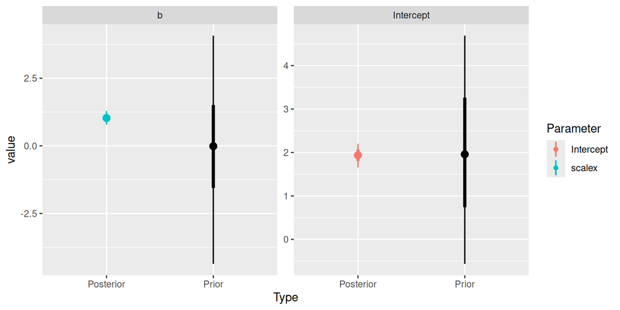

```r
dat3c.brm2 |> SUYR_prior_and_posterior()
```

**Conclusions:**

- each of the priors are substantially wider than the posteriors
- the posteriors are definitely distinct from their respective priors and thus we can conclude that the priors and not driving the posteriors (e.g. they are not influencing the outcomes)
- the priors are simply regularising the parameters such that they are only sampled from plausible regions

**Example 5 (Binary data)**

**Raw predictor**

$$\begin{align}
y_i \sim{}& Bin(\pi_i, 1)\\
log(\frac{\pi_i}{1-\pi_i}) =& \beta_0 + \beta_1 x_i\\
\end{align}$$

**Define priors**

When considering priors, it is important to remember that they apply to parameters on the link scale. For Binary models, the link scale is logit. Binomial data is notoriously difficult to define priors for. Nevertheless the following considerations are useful:

- the observed response values are only ever either 0 or 1
- a linear model is exploring whether the probability of a 1 changes from high to low or low to high according to the linear predictor
- the switch in probability is likely to be somewhere near the middle of the $x$ range
- with a centered predictor, the mean response is expected to be approximately 0.5
- on a logit (log odds) scale, this corresponds to a value of 0.
- on a logit (log odds) scale, values of -3 and 3 are considered very wide
- on a logit scale, values between -1 and 1 are reasonable.

So the following priors might be appropriate:

- $\beta_0$: Normal prior centred at 0 with a variance of 1
- $\beta_1$: *t* distribution (3 degrees of freedom) prior centred at 0 with a variance of 1

```r
priors <- prior(normal(0, 1), class = "Intercept") +
    prior(student_t(3, 0, 1), class = "b")
```

**Fit the model**

1. start by fitting the model and sampling from the priors only

```r
dat5a.form <- bf(y ~ x, family = bernoulli(link = "logit"))
dat5a.brm <- brm(dat5a.form,
                data=dat5,
                prior=priors,
                sample_prior = 'only',
                iter = 5000,
                warmup = 1000,
                chains = 3, cores = 3,
                thin = 5,
                #backend = 'cmdstan',
                refresh = 0)
```

2. explore the range of posterior predictions resulting from the priors alone

For Binary data, it is often more useful to explore the predictions on the link scale. Ribbons that extend much beyond -3 and 3 would definitely be considered wide enough.

```
Ignoring unknown labels:
• fill : "NA"
• colour : "NA"
Ignoring unknown labels:
• fill : "NA"
• colour : "NA"
```

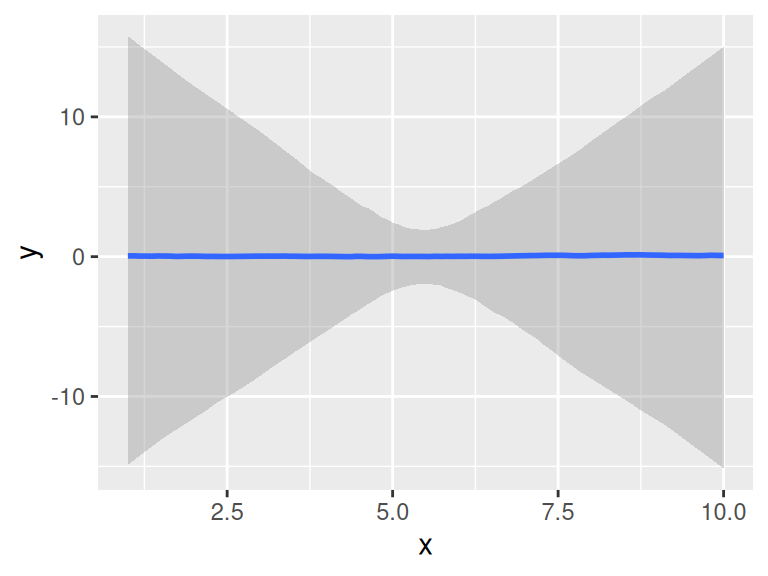

```r
dat5a.brm |>
  conditional_effects(method = "posterior_linpred")
```

```
Ignoring unknown labels:
• fill : "NA"
• colour : "NA"
Ignoring unknown labels:
• fill : "NA"
• colour : "NA"
```

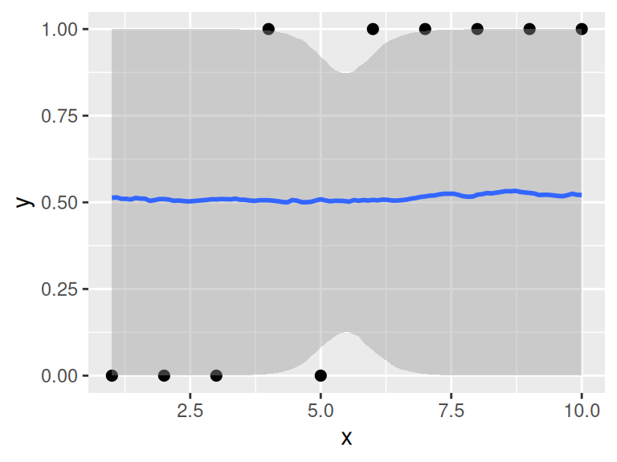

```r
dat5a.brm |>
  conditional_effects() |>
  plot(points = TRUE)
```

**Conclusions:**

```r
dat5a.brm2 <- update(dat5a.brm,
    sample_prior = "yes"
)
```

```
The desired updates require recompiling the model
```

4. re-explore the range of posterior predictions resulting from the fitted model

```
Ignoring unknown labels:
• fill : "NA"
• colour : "NA"
Ignoring unknown labels:
• fill : "NA"
• colour : "NA"
```

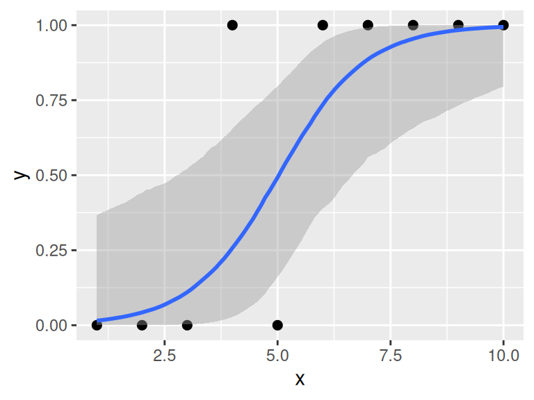

```r
dat5a.brm2 |>
    conditional_effects() |>
    plot(points = TRUE)
```

**Conclusions:**

- the range of the posteriors are now substantially reduced (now that the model includes both data and priors)
- this suggests that the patterns are being driven predominantly by the data
5. compare the priors and posteriors to further confirm that the priors are not overly influential

When we have indicated that the posterior should be informed by both the prior and the posterior, both prior (governed by priors alone) and posterior (governed by both priors and data/likelihood) draws are returned. These can be compared by exploring the probabilities associated with specific hypotheses - the most obvious of which is that of no effect (that the parameter = 0).

When doing so, ideally the posterior should be distinct from the prior. By distinct, I mean that the posteriors should be clearly distinguishable from the priors. Ideally, the priors should be less variable than the priors. If this is not the case, it might suggest that the posteriors are being too strongly driven by the priors.

```r
dat5a.brm2 |> tidybayes::get_variables()
```

```
 [1] "b_Intercept"     "b_x"             "Intercept"       "prior_Intercept"
 [5] "prior_b"         "lprior"          "lp__"            "accept_stat__"
 [9] "stepsize__"      "treedepth__"     "n_leapfrog__"    "divergent__"
[13] "energy__"
```

```r
dat5a.brm2 |> hypothesis("x = 0") |> plot()
```

[output not shown]

Unfortunately, it is not possible to do this comparison sensibly for the intercept. The reason for this is that the prior for intercept was applied to an intercept that is associated with centred continuous predictors (predictors are centred behind the scenes). Since we did not centre the predictor, the intercept returned is as if uncentred. Hence, the prior and posterior are on different scales.

```r
dat5a.brm2 |> tidybayes::get_variables()
```

```
 [1] "b_Intercept"     "b_x"             "Intercept"       "prior_Intercept"
 [5] "prior_b"         "lprior"          "lp__"            "accept_stat__"
 [9] "stepsize__"      "treedepth__"     "n_leapfrog__"    "divergent__"
[13] "energy__"
```

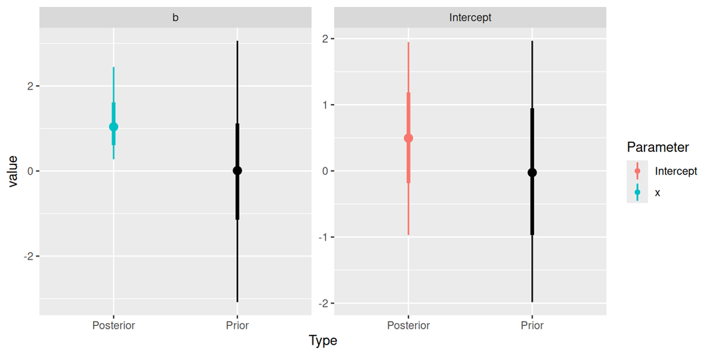

```r
dat5a.brm2 |> SUYR_prior_and_posterior()
```

**Conclusions:**

**Standardised predictor**

$$\begin{align}
y_i \sim{}& Bin(\pi_i, 1)\\
log(\frac{\pi_i}{1 -\pi_i}) =& \beta_0 + (\beta_1 x_i - \bar{x})/\sigma_x\\
\end{align}$$

**Define priors**

- $\beta_0$: Normal prior centred at 0 with a variance of 1
- $\beta_1$: *t* distribution (3 degrees of freedom) prior centred at 0 with a variance of 1

```r
priors <- prior(normal(0, 1), class = "Intercept") +
    prior(student_t(3, 0, 1), class = "b")
```

**Fit the model**

1. start by fitting the model and sampling from the priors only

```r
dat5c.form <- bf(y ~ scale(x), family = bernoulli(link = "logit"))
dat5c.brm <- brm(dat5c.form,
                data=dat5,
                prior=priors,
                sample_prior = 'only',
                iter = 5000,
                warmup = 1000,
                chains = 3, cores = 3,
                thin = 5,
                #backend = 'cmdstan',
                refresh = 0)
```

2. explore the range of posterior predictions resulting from the priors alone

```
Ignoring unknown labels:
• fill : "NA"
• colour : "NA"
Ignoring unknown labels:
• fill : "NA"
• colour : "NA"
```

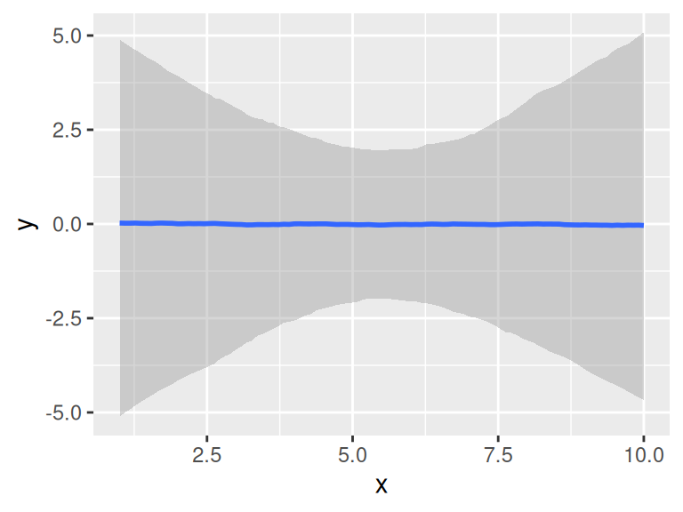

```r
dat5c.brm |>
  conditional_effects(method = "posterior_linpred")
```

**Conclusions:**

```r
dat5c.brm2 <- update(dat5c.brm,
    sample_prior = "yes"
)
```

```
The desired updates require recompiling the model
```

4. re-explore the range of posterior predictions resulting from the fitted model

```
Ignoring unknown labels:
• fill : "NA"
• colour : "NA"
Ignoring unknown labels:
• fill : "NA"
• colour : "NA"
```

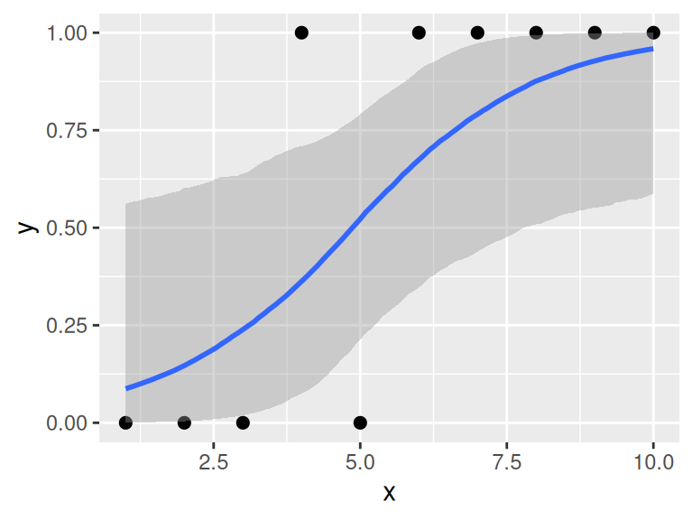

```r
dat5c.brm2 |>
    conditional_effects() |>
    plot(points = TRUE)
```

**Conclusions:**

- the range of the posteriors are now substantially reduced (now that the model includes both data and priors)
- this suggests that the patterns are being driven predominantly by the data
5. compare the priors and posteriors to further confirm that the priors are not overly influential

When we have indicated that the posterior should be informed by both the prior and the posterior, both prior (governed by priors alone) and posterior (governed by both priors and data/likelihood) draws are returned. These can be compared by exploring the probabilities associated with specific hypotheses - the most obvious of which is that of no effect (that the parameter = 0).

When doing so, ideally the posterior should be distinct from the prior. By distinct, I mean that the posteriors should be clearly distinguishable from the priors. Ideally, the priors should be less variable than the priors. If this is not the case, it might suggest that the posteriors are being too strongly driven by the priors.

```r
dat5c.brm2 |> tidybayes::get_variables()
```

```
 [1] "b_Intercept"     "b_scalex"        "Intercept"       "prior_Intercept"
 [5] "prior_b"         "lprior"          "lp__"            "accept_stat__"
 [9] "stepsize__"      "treedepth__"     "n_leapfrog__"    "divergent__"
[13] "energy__"
```

```r
dat5c.brm2 |> hypothesis("scalex = 0") |> plot()
```

[output not shown]

```r
dat5c.brm2 |> tidybayes::get_variables()
```

```
 [1] "b_Intercept"     "b_scalex"        "Intercept"       "prior_Intercept"
 [5] "prior_b"         "lprior"          "lp__"            "accept_stat__"
 [9] "stepsize__"      "treedepth__"     "n_leapfrog__"    "divergent__"
[13] "energy__"
```

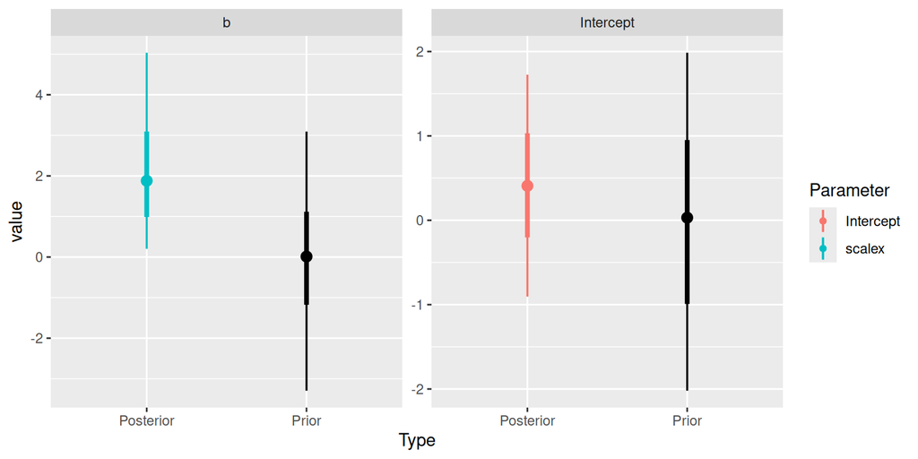

```r
dat5c.brm2 |> SUYR_prior_and_posterior()
```

**Conclusions:**

# 8 MCMC sampling diagnostics

**MCMC sampling behaviour**

Since the purpose of the MCMC sampling is to estimate the posterior of an unknown joint likelihood, it is important that we explore a range of diagnostics designed to help identify when the resulting likelihood might not be accurate.

- **traceplots** - plots of the individual draws in sequence. Traces that resemble noise suggest that all likelihood features are likely to have be traversed. Obvious steps or blocks of noise are likely to represent distinct features and could imply that there are yet other features that have not yet been traversed - necessitating additional iterations. Furthermore, each chain should be indistinguishable from the others

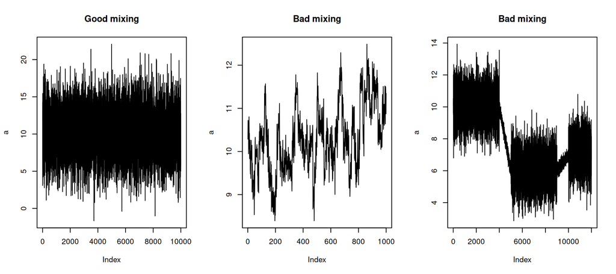

- **autocorrelation function** - plots of the degree of correlation between pairs of draws for a range of lags (distance along the chains). High levels of correlation (after a lag of 0, which is correlating each draw with itself) suggests a lack of independence between the draws and that therefore, summaries such as mean and median will be biased estimates. Ideally, all non-zero lag correlations should be less than 0.2. The left hand figure below demonstrates a clear pattern of autocorrelation, whereas the right hand figure shows no autocorrelation.

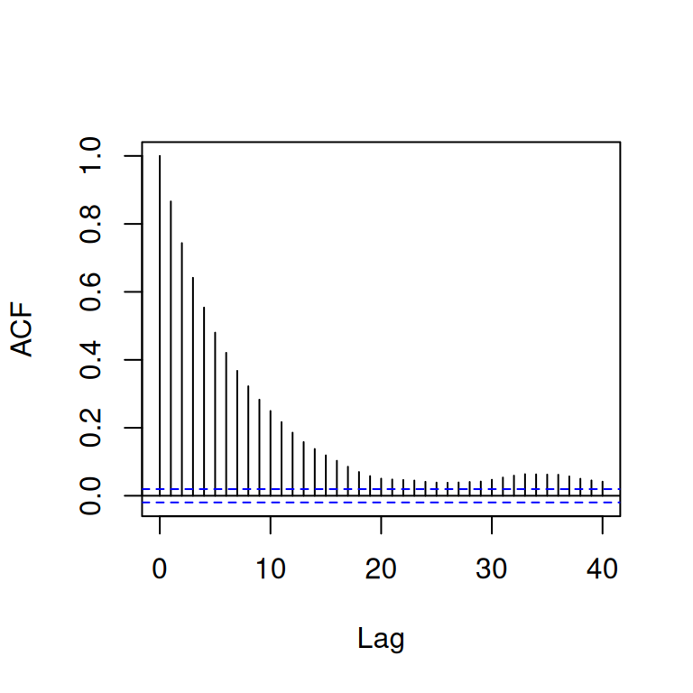

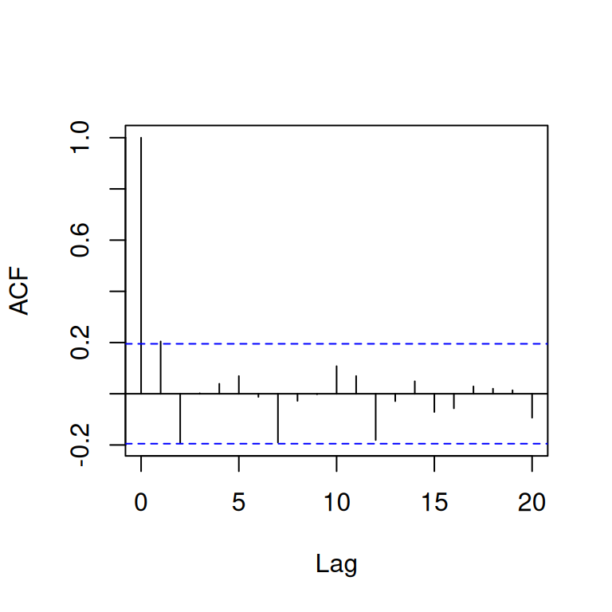

- **convergence diagnostics** - there are a range of diagnostics aimed at exploring whether the multiple chains are likely to have converged upon similar posteriors
  - **R hat** - this metric compares between and within chain model parameter estimates, with the expectation that if the chains have converged, the between and within rank normalised estimates should be very similar (and Rhat should be close to 1). The more one chains deviates from the others, the higher the Rhat value. Values less than 1.05 are considered evidence of convergence.
  - **Bulk ESS** - this is a measure of the effective sample size from the whole (bulk) of the posterior and is a good measure of the sampling efficiency of draws across the entire posterior
  - **Tail ESS** - this is a measure of the effective sample size from the 5% and 95% quantiles (tails) of the posterior and is a good measure of the sampling efficiency of draws from the tail (areas of the posterior with least support and where samplers can get stuck).

There are numerous packages in R that support MCMC diagnostics. Popular packages include:

- `bayesplot`
- `rstan`
- `ggmcmcm`

Some of the most useful diagnostics are presented in the following table.

| Package | Description | function | rstanarm | brms |
| --- | --- | --- | --- | --- |
| bayesplot | Traceplot | `mcmc_trace` | `plot(mod, plotfun='trace')` | `mcmc_plot(mod, type='trace')` |
|  | Density plot | `mcmc_dens` | `plot(mod, plotfun='dens')` | `mcmc_plot(mod, type='dens')` |
|  | Density & Trace | `mcmc_combo` | `plot(mod, plotfun='combo')` | `mcmc_plot(mod, type='combo')` |
|  | ACF | `mcmc_acf_bar` | `plot(mod, plotfun='acf_bar')` | `mcmc_plot(mod, type='acf_bar')` |
|  | Rhat hist | `mcmc_rhat_hist` | `plot(mod, plotfun='rhat_hist')` | `mcmc_plot(mod, type='rhat_hist')` |
|  | No. Effective | `mcmc_neff_hist` | `plot(mod, plotfun='neff_hist')` | `mcmc_plot(mod, type='neff_hist')` |
| rstan | Traceplot | `stan_trace` | `stan_trace(mod)` | `stan_trace(mod)` |
|  | ACF | `stan_ac` | `stan_ac(mod)` | `stan_ac(mod)` |
|  | Rhat | `stan_rhat` | `stan_rhat(mod)` | `stan_rhat(mod)` |
|  | No. Effective | `stan_ess` | `stan_ess(mod)` | `stan_ess(mod)` |
|  | Density plot | `stan_dens` | `stan_dens(mod)` | `stan_dens(mod)` |
| ggmcmc | Traceplot | `ggs_traceplot` | `ggs_traceplot(ggs(mod))` | `ggs_traceplot(ggs(mod))` |
|  | ACF | `ggs_autocorrelation` | `ggs_autocorrelation(ggs(mod))` | `ggs_autocorrelation(ggs(mod))` |
|  | Rhat | `ggs_Rhat` | `ggs_Rhat(ggs(mod))` | `ggs_Rhat(ggs(mod))` |
|  | No. Effective | `ggs_effective` | `ggs_effective(ggs(mod))` | `ggs_effective(ggs(mod))` |
|  | Cross correlation | `ggs_crosscorrelation` | `ggs_crosscorrelation(ggs(mod))` | `ggs_crosscorrelation(ggs(mod))` |
|  | Scale reduction | `ggs_grb` | `ggs_grb(ggs(mod))` | `ggs_grb(ggs(mod))` |

I personally prefer the `rstan` version of plots and thus these are the ones I will showcase.

**Example 1 (Gaussian data)**

**Note**

Bayesian samplers involve many calls to randomisation functions. As a result, the estimates will vary slightly each time the routines are run. You should expect that the outputs that you obtain will differ slightly from those that I am displaying. Nevertheless, the main conclusions should remain robust across subsequent runs.

**Raw predictor**

**Traceplots**

Plots of the estimates of each parameter over the post-warmup length of each MCMC chain. Each chain is plotted in a different colour, with each parameter in its own facet. Ideally, each **trace** should just look like noise without any discernible drift and each of the traces for a specific parameter should look the same (i.e, should not be displaced above or below any other trace for that parameter).

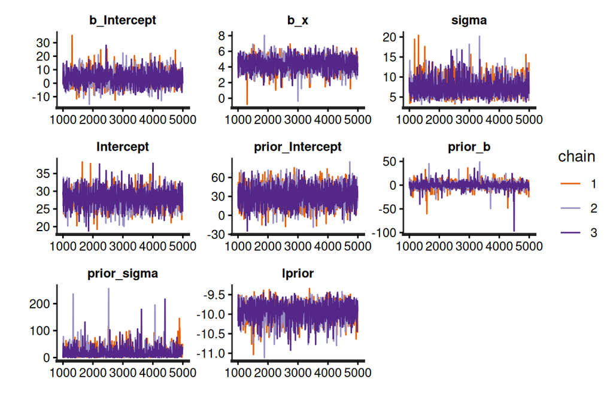

```r
dat1a.brm2$fit |> stan_trace()
```

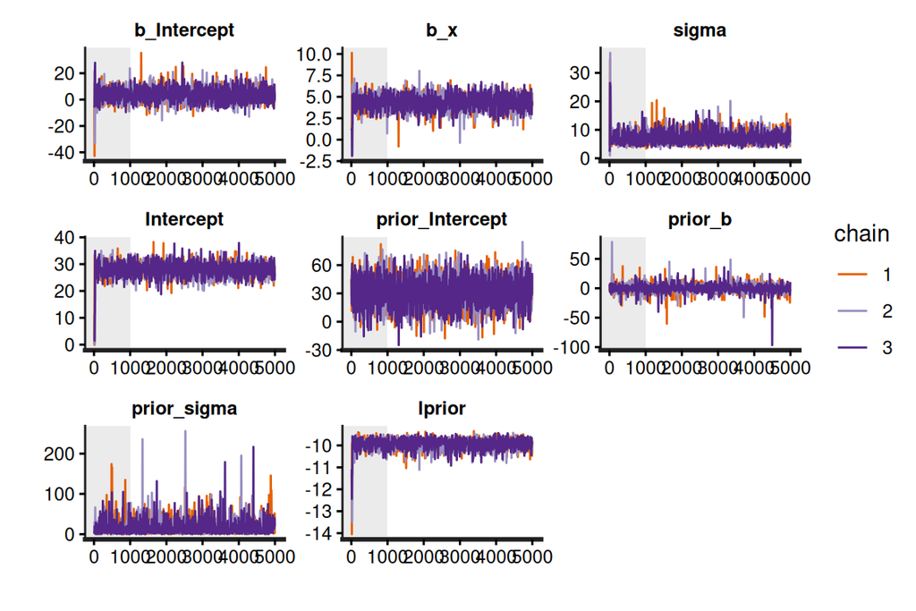

```r
dat1a.brm2$fit |> stan_trace(inc_warmup = TRUE)
```

**Conclusions**:

```
- the chains appear well mixed and very similar
```

**Autocorrelation plots**

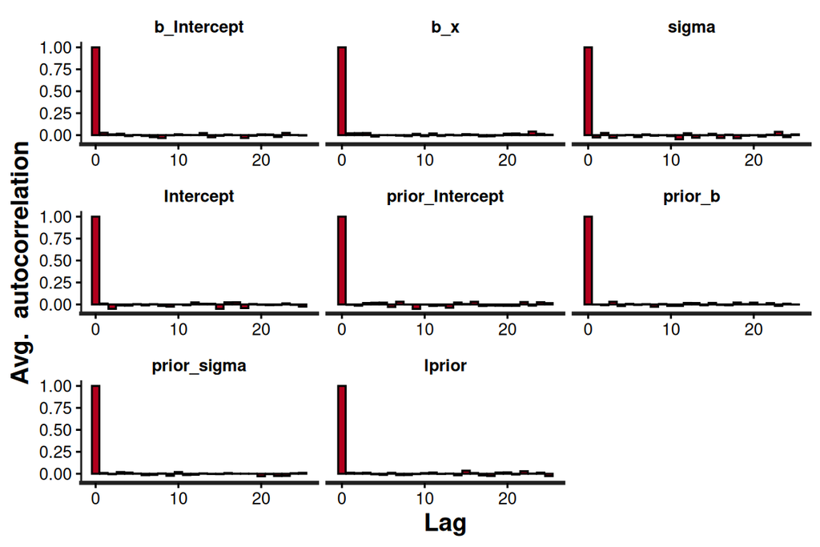

```r
dat1a.brm2$fit |> stan_ac()
```

**Conclusions**:

- there is no evidence of autocorrelation in the MCMC samples

**Rhat**

Rhat is a **scale reduction factor** measure of convergence between the chains. The closer the values are to 1, the more the chains have converged. Values greater than 1.05 indicate a lack of convergence. There will be an Rhat value for each parameter estimated.

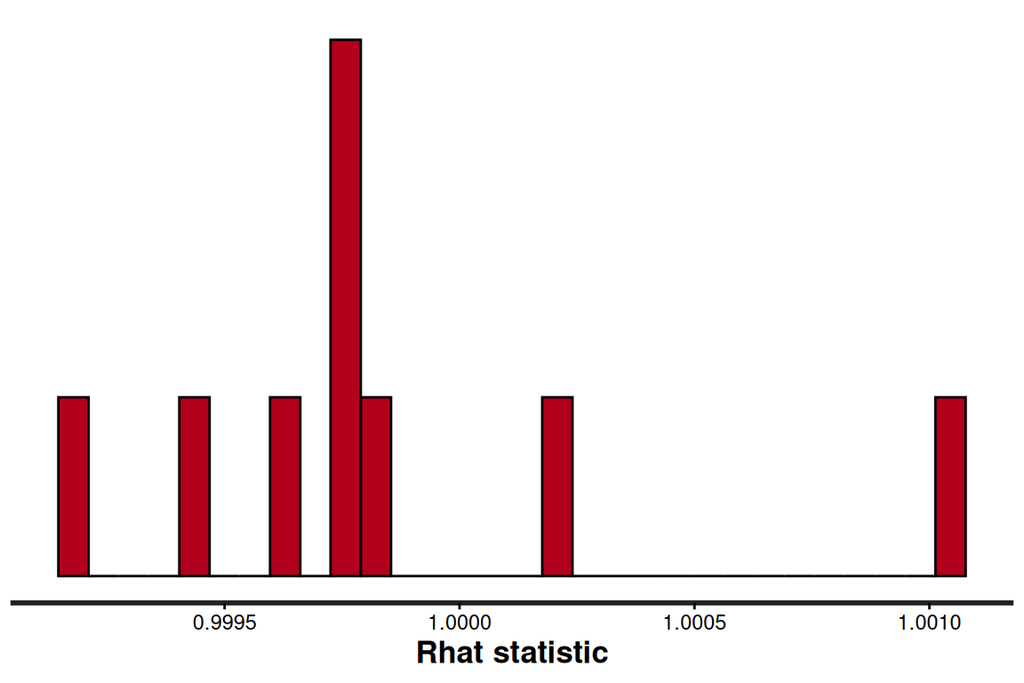

```r
dat1a.brm2$fit |> stan_rhat()
```

**Conclusions**:

- all Rhat values are below 1.05, suggesting the chains have converged.

**Effective sample sizes**

The number of effective samples - the ratio of the number of effective samples (those not rejected by the sampler) to the number of samples provides an indication of the effectiveness (and efficiency) of the MCMC sampler. Ratios that are less than 0.5 for a parameter suggest that the sampler spent considerable time in difficult areas of the sampling domain and rejected more than half of the samples (replacing them with the previous effective sample).

If the ratios are low, tightening the priors may help.

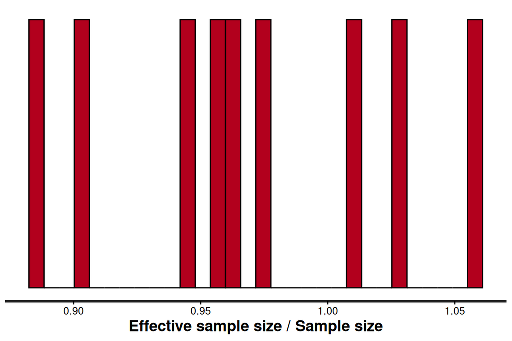

```r
dat1a.brm2$fit |> stan_ess()
```

**Conclusions**:

- ratios are all very high

**Conclusions**:

- all the diagnostics appear reasonable
- we can conclude that the chains are all well mixed and have converged on a stable posterior.

**Centered predictor**

**Traceplots**

Plots of the estimates of each parameter over the post-warmup length of each MCMC chain. Each chain is plotted in a different colour, with each parameter in its own facet. Ideally, each **trace** should just look like noise without any discernible drift and each of the traces for a specific parameter should look the same (i.e, should not be displaced above or below any other trace for that parameter).

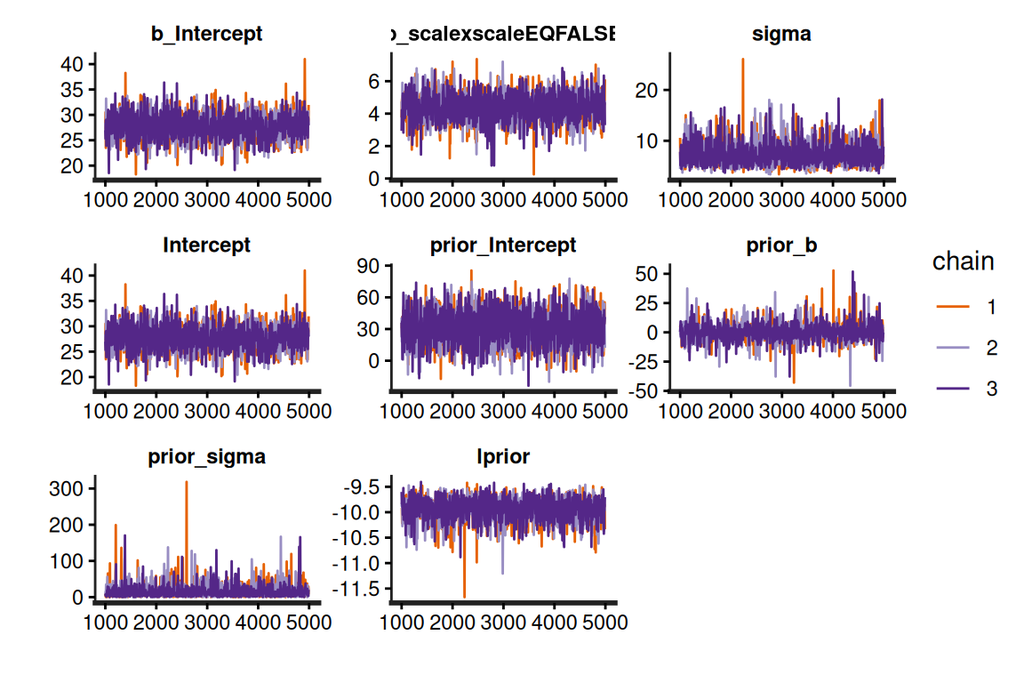

```r
dat1b.brm2$fit |> stan_trace()
```

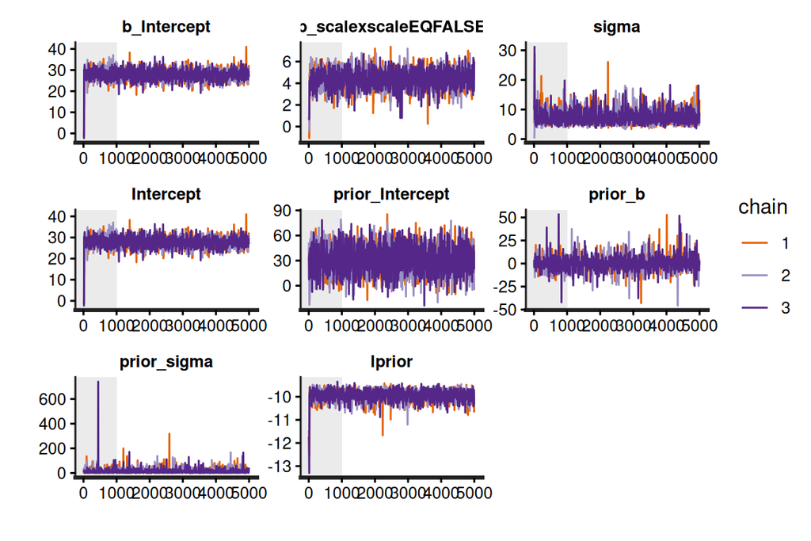

```r
dat1b.brm2$fit |> stan_trace(inc_warmup = TRUE)
```

**Conclusions**:

```
- the chains appear well mixed and very similar
```

**Autocorrelation plots**

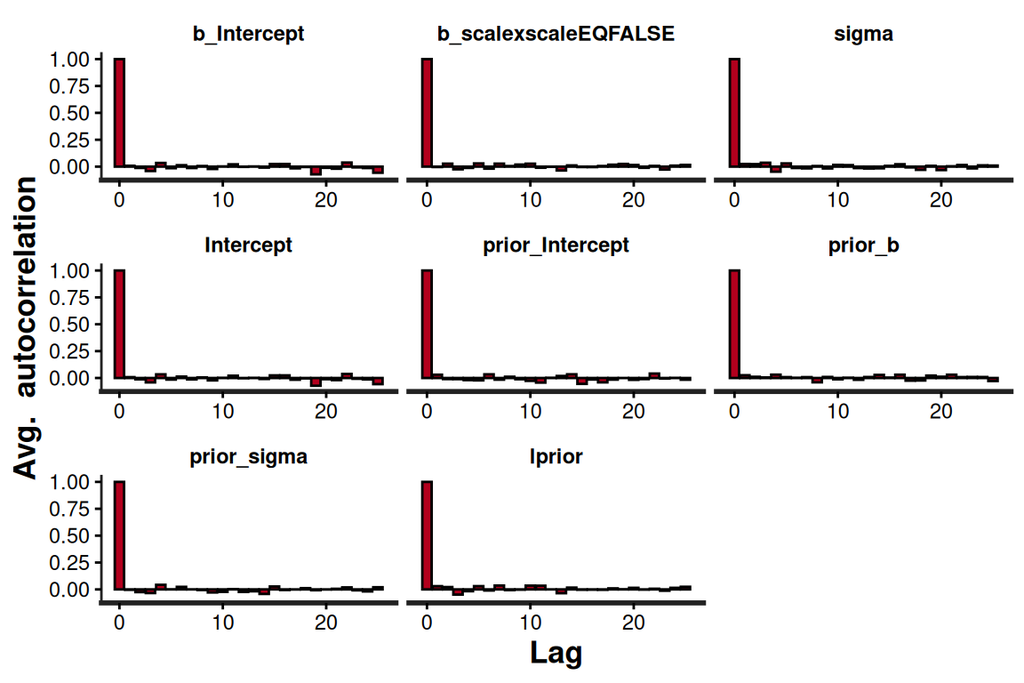

```r
dat1b.brm2$fit |> stan_ac()
```

**Conclusions**:

- there is no evidence of autocorrelation in the MCMC samples

**Rhat**

Rhat is a **scale reduction factor** measure of convergence between the chains. The closer the values are to 1, the more the chains have converged. Values greater than 1.05 indicate a lack of convergence. There will be an Rhat value for each parameter estimated.

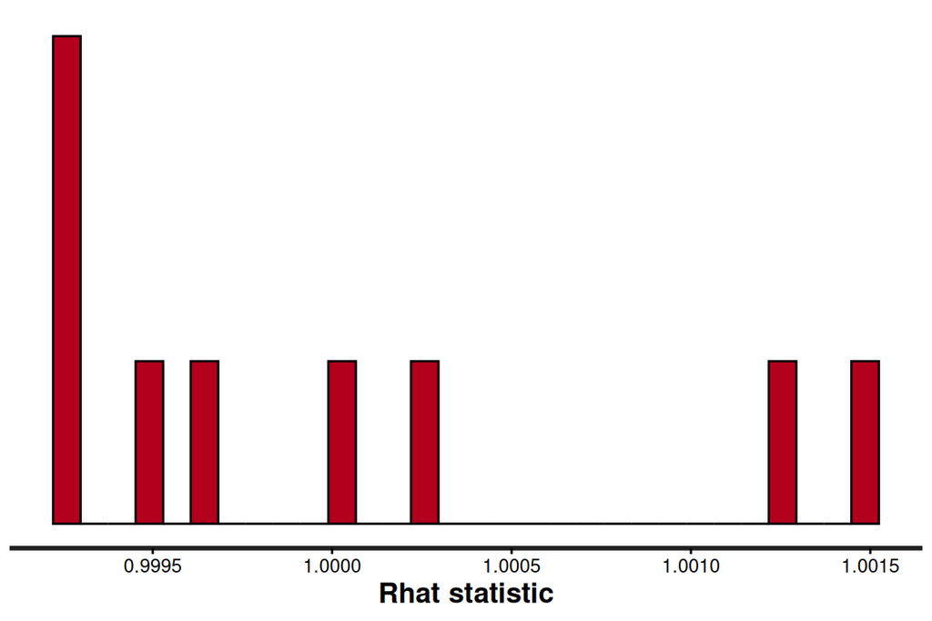

```r
dat1b.brm2$fit |> stan_rhat()
```

**Conclusions**:

- all Rhat values are below 1.05, suggesting the chains have converged.

**Effective sample sizes**

The number of effective samples - the ratio of the number of effective samples (those not rejected by the sampler) to the number of samples provides an indication of the effectiveness (and efficiency) of the MCMC sampler. Ratios that are less than 0.5 for a parameter suggest that the sampler spent considerable time in difficult areas of the sampling domain and rejected more than half of the samples (replacing them with the previous effective sample).

If the ratios are low, tightening the priors may help.

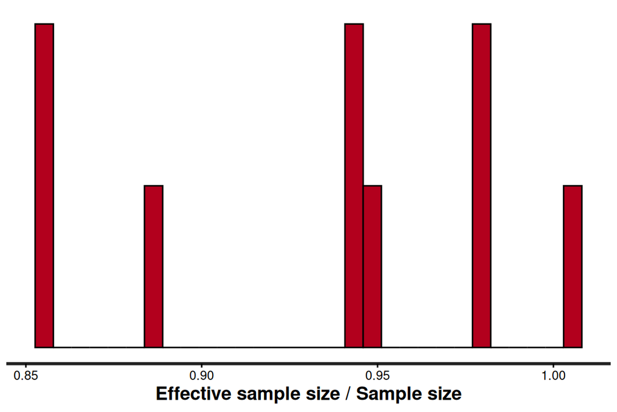

```r
dat1b.brm2$fit |> stan_ess()
```

**Conclusions**:

- ratios are all very high